# Carry column metadata in pivot_longer

Nick Carruthers

15/06/2020

#### Background:

Lots of bioinformatics workflows require both **long** and **wide** data. **Wide** data is the most common output format generated by proteomics search engines: each row is a protein and columns are samples. Each cell contains a quantitative value like abundance. **Long** data will have a single column for the quantitative values and two columns to indicate row and sample. To me the advantages of using **long** data are (1) that it provides a unified format for any required data manipulations and summarizations and (2) that it is the required input format for the ggplot system. In R [the tidyverse](https://www.tidyverse.org/) provides the tools to go from one to another.

#### The Problem:

Typically samples (columns) will have associated metadata like treatments and indicators of groups or replicates. Any metadata that corresponds to rows can be easily added to the data.frame to be pivoted (eg. with cbind). But if there are both row and column metadata how can the latter be included in the long format.

#### The Solution:

There are a couple of options. My favorite way is to convert a key column to an ordered factor and then “map” the metadata to it. I see the ordered factor as a benefit as it is often required to control plot order in ggplot.

```r
head(relig_income)
```

```
## # A tibble: 6 x 11
##   religion `<$10k` `$10-20k` `$20-30k` `$30-40k` `$40-50k` `$50-75k` `$75-100k`
##   <chr>      <dbl>     <dbl>     <dbl>     <dbl>     <dbl>     <dbl>      <dbl>
## 1 Agnostic      27        34        60        81        76       137        122
## 2 Atheist       12        27        37        52        35        70         73
## 3 Buddhist      27        21        30        34        33        58         62
## 4 Catholic     418       617       732       670       638      1116        949
## 5 Don’t k~      15        14        15        11        10        35         21
## 6 Evangel~     575       869      1064       982       881      1486        949
## # ... with 3 more variables: `$100-150k` <dbl>, `>150k` <dbl>, `Don't
## #   know/refused` <dbl>
```

#### First, create the metadata.

This only applies to data with both row and column metadata. I’ll use the `relig_income` dataset as an example. To make this a suitable example I will add a random column for religion class and group income levels into low, medium, high and unknown listed in a separate `data.frame`. Note that this method relies on the column metadata being complete and accurate so check that table carefully!

```r
## Row metadata
set.seed(10)
relig_income$religionClass <-
  sample(c("A", "B", "C"), nrow(relig_income), replace = TRUE)

## Column metadata
columnMetadata <- data.frame(
  income = c(colnames(relig_income)[
    grepl("0", colnames(relig_income))],
    "Don't know/refused"),
  incomeGroup = c(rep("low", 3), rep("medium", 3),
            rep("high", 3), "Don't know/refused"))
columnMetadata
```

```
##                income        incomeGroup
## 1               <$10k                low
## 2             $10-20k                low
## 3             $20-30k                low
## 4             $30-40k             medium
## 5             $40-50k             medium
## 6             $50-75k             medium
## 7            $75-100k               high
## 8           $100-150k               high
## 9               >150k               high
## 10 Don't know/refused Don't know/refused
```

#### Step 1: pivot_longer as usual

```r
relig_income %>%
  pivot_longer(-c(religion, religionClass), names_to = "income", values_to = "count")
```

```
## # A tibble: 180 x 4
##    religion religionClass income             count
##    <chr>    <chr>         <chr>              <dbl>
##  1 Agnostic C             <$10k                 27
##  2 Agnostic C             $10-20k               34
##  3 Agnostic C             $20-30k               60
##  4 Agnostic C             $30-40k               81
##  5 Agnostic C             $40-50k               76
##  6 Agnostic C             $50-75k              137
##  7 Agnostic C             $75-100k             122
##  8 Agnostic C             $100-150k            109
##  9 Agnostic C             >150k                 84
## 10 Agnostic C             Don't know/refused    96
## # ... with 170 more rows
```

#### Step 2: convert key column to an ordered factor

This has the added benefit that it controls the order of this column when plotting

```r
relig_income %>%
  pivot_longer(-c(religion, religionClass), names_to = "income", values_to = "count") %>%
  mutate(income = ordered(income, levels = columnMetadata$income))
```

```
## # A tibble: 180 x 4
##    religion religionClass income             count
##    <chr>    <chr>         <ord>              <dbl>
##  1 Agnostic C             <$10k                 27
##  2 Agnostic C             $10-20k               34
##  3 Agnostic C             $20-30k               60
##  4 Agnostic C             $30-40k               81
##  5 Agnostic C             $40-50k               76
##  6 Agnostic C             $50-75k              137
##  7 Agnostic C             $75-100k             122
##  8 Agnostic C             $100-150k            109
##  9 Agnostic C             >150k                 84
## 10 Agnostic C             Don't know/refused    96
## # ... with 170 more rows
```

#### Step 3: Use the factor levels to map the new data

```r
relig_income %>%
  pivot_longer(-c(religion, religionClass), names_to = "income", values_to = "count") %>%
  mutate(income = ordered(income, levels = columnMetadata$income)) %>%
  mutate(incomeClass = columnMetadata$incomeGroup[income])
```

```
## # A tibble: 180 x 5
##    religion religionClass income             count incomeClass
##    <chr>    <chr>         <ord>              <dbl> <chr>
##  1 Agnostic C             <$10k                 27 low
##  2 Agnostic C             $10-20k               34 low
##  3 Agnostic C             $20-30k               60 low
##  4 Agnostic C             $30-40k               81 medium
##  5 Agnostic C             $40-50k               76 medium
##  6 Agnostic C             $50-75k              137 medium
##  7 Agnostic C             $75-100k             122 high
##  8 Agnostic C             $100-150k            109 high
##  9 Agnostic C             >150k                 84 high
## 10 Agnostic C             Don't know/refused    96 Don't know/refused
## # ... with 170 more rows
```

Finally it’s a good idea to make a look at the mapping to ensure it worked.

```r
test <- relig_income %>%
  pivot_longer(-c(religion, religionClass), names_to = "income", values_to = "count") %>%
  mutate(income = ordered(income, levels = columnMetadata$income)) %>%
  mutate(incomeClass = columnMetadata$incomeGroup[income])

table(test$income, test$incomeClass)
```

```
##
##                      Don't know/refused high low medium
##   <$10k                               0    0  18      0
##   $10-20k                             0    0  18      0
##   $20-30k                             0    0  18      0
##   $30-40k                             0    0   0     18
##   $40-50k                             0    0   0     18
##   $50-75k                             0    0   0     18
##   $75-100k                            0   18   0      0
##   $100-150k                           0   18   0      0
##   >150k                               0   18   0      0
##   Don't know/refused                 18    0   0      0
```

#### The metadata columns are now available

We can plot the data faceted by our arbitrary grouping of religions and colored by our grouped income levels.

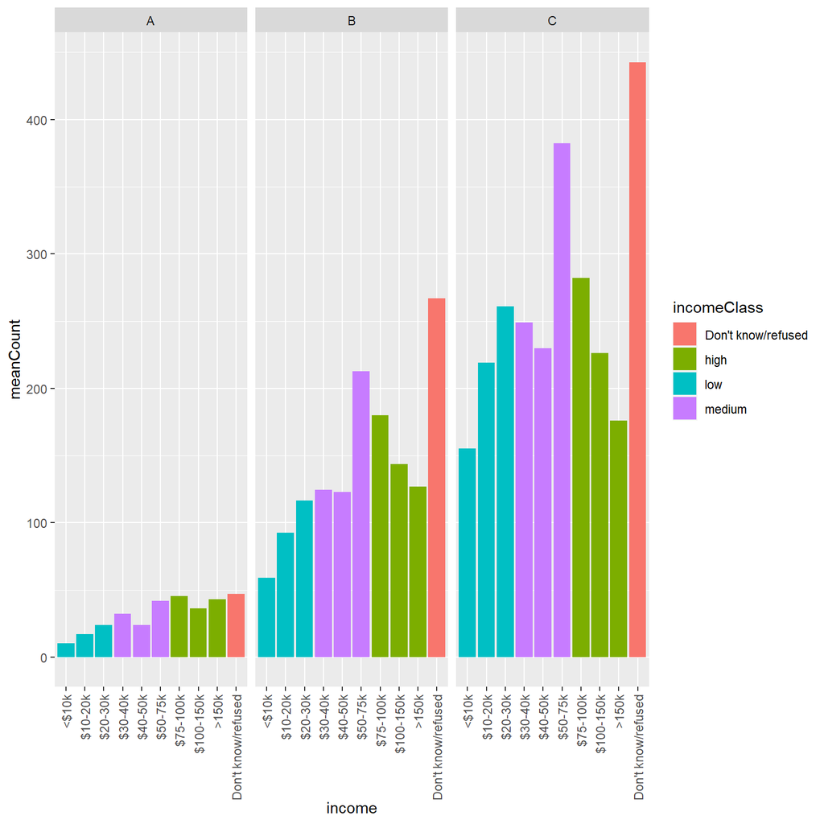

```r
relig_income %>%
  pivot_longer(-c(religion, religionClass), names_to = "income", values_to = "count") %>%
  mutate(income = ordered(income, levels = columnMetadata$income)) %>%
  mutate(incomeClass = columnMetadata$incomeGroup[income]) %>%
  group_by(religionClass, income, incomeClass) %>%
  summarize(meanCount = mean(count)) %>%
  ggplot(aes(x = income, y = meanCount, fill = incomeClass)) +
  geom_col() +
  facet_wrap(vars(religionClass)) +
  theme(axis.text.x = element_text(angle = 90, vjust = 0.5, hjust=1))
```